# Data Clearning and Exploratory Data Analysis

```python
import pandas as pd
import numpy as np
from pandas.plotting import scatter_matrix
import matplotlib.pyplot as plt
import seaborn as sns
import math
from copy import deepcopy
import missingno as msno
%matplotlib inline
```

```python
df = pd.read_csv("WA_Fn-UseC_-Telco-Customer-Churn.csv")
```

## Exploratory Data Analysis

While exploring the data, it is important to keep in mind the purpose and use case for the analysis. We are using this data set to Predict Customer Churn. Customer churn is the loss of clients or customers.

As we explore the data, we gain more insights as to how we should proceed or use it, such as perhaps removing invalid data, and deciding which data we want to use in our model. Analysis will be carried out in the order of finding out the correlation between variables, followed by univariate analysis and bivariate analysis (variable's effect on target).

**We are analysing based on the principle of parsimony, which states that good modelers try to have as simple a model as possible. Thus, we will try to obtain a model with the fewest number of explanatory variables (Evans 258).**

```python
# To understand how many observation points and columns we have
print(df.shape)
```

```
(7043, 21)
```

```python
# To better understand and interpret the data types, it is best to see a few data points
df.head()
```

|  | customerID | gender | SeniorCitizen | Partner | Dependents | tenure | PhoneService | MultipleLines | InternetService | OnlineSecurity | ... | DeviceProtection | TechSupport | StreamingTV | StreamingMovies | Contract | PaperlessBilling | PaymentMethod | MonthlyCharges | TotalCharges | Churn |
| --- | --- | --- | --- | --- | --- | --- | --- | --- | --- | --- | --- | --- | --- | --- | --- | --- | --- | --- | --- | --- | --- |
| 0 | 7590-VHVEG | Female | 0 | Yes | No | 1 | No | No phone service | DSL | No | ... | No | No | No | No | Month-to-month | Yes | Electronic check | 29.85 | 29.85 | No |
| 1 | 5575-GNVDE | Male | 0 | No | No | 34 | Yes | No | DSL | Yes | ... | Yes | No | No | No | One year | No | Mailed check | 56.95 | 1889.5 | No |
| 2 | 3668-QPYBK | Male | 0 | No | No | 2 | Yes | No | DSL | Yes | ... | No | No | No | No | Month-to-month | Yes | Mailed check | 53.85 | 108.15 | Yes |
| 3 | 7795-CFOCW | Male | 0 | No | No | 45 | No | No phone service | DSL | Yes | ... | Yes | Yes | No | No | One year | No | Bank transfer (automatic) | 42.30 | 1840.75 | No |
| 4 | 9237-HQITU | Female | 0 | No | No | 2 | Yes | No | Fiber optic | No | ... | No | No | No | No | Month-to-month | Yes | Electronic check | 70.70 | 151.65 | Yes |

5 rows × 21 columns

### Visualisation of Missing Data

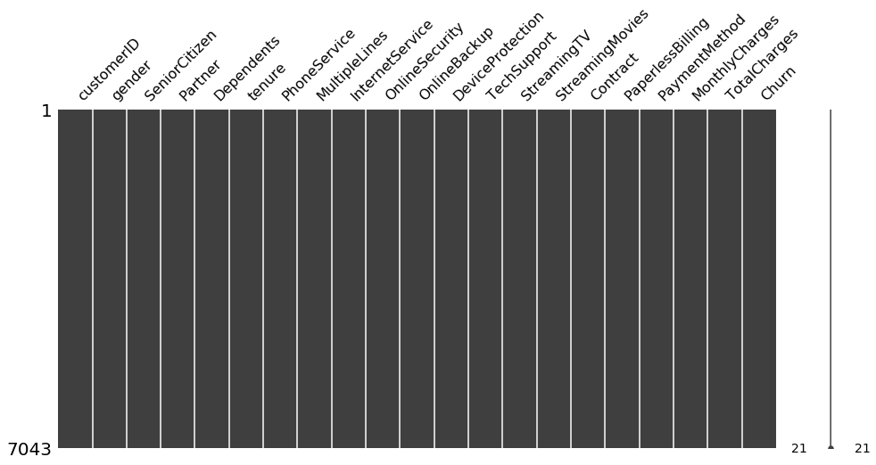

```python
msno.matrix(df, figsize=(16,7))
```

```python
df.describe().T
```

|  | count | mean | std | min | 25% | 50% | 75% | max |
| --- | --- | --- | --- | --- | --- | --- | --- | --- |
| SeniorCitizen | 7043.0 | 0.162147 | 0.368612 | 0.00 | 0.0 | 0.00 | 0.00 | 1.00 |
| tenure | 7043.0 | 32.371149 | 24.559481 | 0.00 | 9.0 | 29.00 | 55.00 | 72.00 |
| MonthlyCharges | 7043.0 | 64.761692 | 30.090047 | 18.25 | 35.5 | 70.35 | 89.85 | 118.75 |

We should have expected seniorcitizen, tenure, monthly charges and total chages to appear in the describe cell. Hence, we have to keep in mind that data for total charges might not be clean, and find out the reason behind this behaviour.

```python
columns = df.columns.tolist()
```

```python
# This function returns a dictionary of column names and the number of distinct counts of values
def dictinct_column_counts(df, columns):
    dic = {}
    for col in columns:
        dic[col] = df[col].nunique()
    return dic

df_col_counts = dictinct_column_counts(df, columns)
print(df_col_counts)
```

[output not shown]

```python
for col in df.columns:
    print(col + " : " +str(df[col].unique()))
```

```
customerID : ['7590-VHVEG' '5575-GNVDE' '3668-QPYBK' ... '4801-JZAZL' '8361-LTMKD'
 '3186-AJIEK']
gender : ['Female' 'Male']
SeniorCitizen : [0 1]
Partner : ['Yes' 'No']
Dependents : ['No' 'Yes']
tenure : [ 1 34  2 45  8 22 10 28 62 13 16 58 49 25 69 52 71 21 12 30 47 72 17 27
  5 46 11 70 63 43 15 60 18 66  9  3 31 50 64 56  7 42 35 48 29 65 38 68
 32 55 37 36 41  6  4 33 67 23 57 61 14 20 53 40 59 24 44 19 54 51 26  0
 39]
PhoneService : ['No' 'Yes']
MultipleLines : ['No phone service' 'No' 'Yes']
InternetService : ['DSL' 'Fiber optic' 'No']
OnlineSecurity : ['No' 'Yes' 'No internet service']
OnlineBackup : ['Yes' 'No' 'No internet service']
DeviceProtection : ['No' 'Yes' 'No internet service']
TechSupport : ['No' 'Yes' 'No internet service']
StreamingTV : ['No' 'Yes' 'No internet service']
StreamingMovies : ['No' 'Yes' 'No internet service']
Contract : ['Month-to-month' 'One year' 'Two year']
PaperlessBilling : ['Yes' 'No']
PaymentMethod : ['Electronic check' 'Mailed check' 'Bank transfer (automatic)'
 'Credit card (automatic)']
MonthlyCharges : [29.85 56.95 53.85 ... 63.1  44.2  78.7 ]
TotalCharges : ['29.85' '1889.5' '108.15' ... '346.45' '306.6' '6844.5']
Churn : ['No' 'Yes']
```

From the distinct column counts, we can get a better sense of the data and its type.

CustomerID is the individual customer ID distinct to each customer. We can infer this because examples such as 7590-VHVEG do not have any other meaning, and the number of distinct customerIDs is equal to the number of rows in the dataset. This will be treated as an 'ignore' attribute, corresponding to variables that are of no significance for the prediction task itself, only for identification pusposes.

The **Target** is Churn.  
The **Continuous Variables** are: Tenure, Monthly Charges, Total Charges.  
The **Categorical Variables** are: gender, SeniorCitizen, Partner, Dependents, PhoneService, MultipleLines, InternetService, OnlineSecurity, OnlineBackup, DeviceProtection, TechSupport, StreamingTV, StreamingMovies, Contract, PaperlessBilling, PaymentMethod

We will perform further analysis to

1. Check for missing/wrong data.
2. Understand the data; relationships that variables have on each other
3. Understand correlations and decide which data to use for the classification model.

# Target Variable

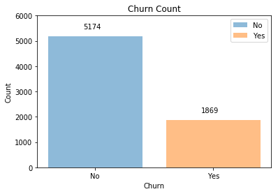

```python
churn_stats = df.groupby("Churn").agg("count")

plt.bar(0, churn_stats.gender[0], align='center', alpha=0.5, label="No")
plt.bar(1, churn_stats.gender[1], align='center', alpha=0.5, label="Yes")
plt.xticks([0,1], ("No", "Yes"))
plt.xlabel("Churn")
plt.ylabel("Count")
plt.title("Churn Count")
plt.ylim(0,6000)
plt.legend()

label = churn_stats.gender
# Text on the top of each barplot
for i in range(len(label)):
    plt.text(x = i-0.1 , y = label[i]+300, s = label[i], size = 10)
```

# Continuous Variables

Variables: Tenure, Monthly Charges, Total Charges.

First, we proceed to understand the data and what it represents, clean if necessary, and then check for correlations with the target.

```python
# First, we should analyse TotalCharges as we have determined it to potentially have invalid variables.

continuous = ['tenure', 'MonthlyCharges', 'TotalCharges']
#pd.to_numeric(df['TotalCharges'])
dirty_data = []
a = 0

# This for loop checks if the data can be converted to a float, if it cannot,
# that would be the unclean data.
for value in df['TotalCharges'].tolist():
    try:
        a = float(value)
    except:
        dirty_data.append(value)

print(dirty_data)
```

```
[' ', ' ', ' ', ' ', ' ', ' ', ' ', ' ', ' ', ' ', ' ']
```

```python
unclean_df = df[df['TotalCharges'] == ' ']
unclean_df.head(20)
```

|  | customerID | gender | SeniorCitizen | Partner | Dependents | tenure | PhoneService | MultipleLines | InternetService | OnlineSecurity | ... | DeviceProtection | TechSupport | StreamingTV | StreamingMovies | Contract | PaperlessBilling | PaymentMethod | MonthlyCharges | TotalCharges | Churn |
| --- | --- | --- | --- | --- | --- | --- | --- | --- | --- | --- | --- | --- | --- | --- | --- | --- | --- | --- | --- | --- | --- |
| 488 | 4472-LVYGI | Female | 0 | Yes | Yes | 0 | No | No phone service | DSL | Yes | ... | Yes | Yes | Yes | No | Two year | Yes | Bank transfer (automatic) | 52.55 |  | No |
| 753 | 3115-CZMZD | Male | 0 | No | Yes | 0 | Yes | No | No | No internet service | ... | No internet service | No internet service | No internet service | No internet service | Two year | No | Mailed check | 20.25 |  | No |
| 936 | 5709-LVOEQ | Female | 0 | Yes | Yes | 0 | Yes | No | DSL | Yes | ... | Yes | No | Yes | Yes | Two year | No | Mailed check | 80.85 |  | No |
| 1082 | 4367-NUYAO | Male | 0 | Yes | Yes | 0 | Yes | Yes | No | No internet service | ... | No internet service | No internet service | No internet service | No internet service | Two year | No | Mailed check | 25.75 |  | No |
| 1340 | 1371-DWPAZ | Female | 0 | Yes | Yes | 0 | No | No phone service | DSL | Yes | ... | Yes | Yes | Yes | No | Two year | No | Credit card (automatic) | 56.05 |  | No |
| 3331 | 7644-OMVMY | Male | 0 | Yes | Yes | 0 | Yes | No | No | No internet service | ... | No internet service | No internet service | No internet service | No internet service | Two year | No | Mailed check | 19.85 |  | No |
| 3826 | 3213-VVOLG | Male | 0 | Yes | Yes | 0 | Yes | Yes | No | No internet service | ... | No internet service | No internet service | No internet service | No internet service | Two year | No | Mailed check | 25.35 |  | No |
| 4380 | 2520-SGTTA | Female | 0 | Yes | Yes | 0 | Yes | No | No | No internet service | ... | No internet service | No internet service | No internet service | No internet service | Two year | No | Mailed check | 20.00 |  | No |
| 5218 | 2923-ARZLG | Male | 0 | Yes | Yes | 0 | Yes | No | No | No internet service | ... | No internet service | No internet service | No internet service | No internet service | One year | Yes | Mailed check | 19.70 |  | No |
| 6670 | 4075-WKNIU | Female | 0 | Yes | Yes | 0 | Yes | Yes | DSL | No | ... | Yes | Yes | Yes | No | Two year | No | Mailed check | 73.35 |  | No |
| 6754 | 2775-SEFEE | Male | 0 | No | Yes | 0 | Yes | Yes | DSL | Yes | ... | No | Yes | No | No | Two year | Yes | Bank transfer (automatic) | 61.90 |  | No |

11 rows × 21 columns

```python
no_tenure_df = df[df.tenure == 0]
no_tenure_df.head(20)
```

|  | customerID | gender | SeniorCitizen | Partner | Dependents | tenure | PhoneService | MultipleLines | InternetService | OnlineSecurity | ... | DeviceProtection | TechSupport | StreamingTV | StreamingMovies | Contract | PaperlessBilling | PaymentMethod | MonthlyCharges | TotalCharges | Churn |
| --- | --- | --- | --- | --- | --- | --- | --- | --- | --- | --- | --- | --- | --- | --- | --- | --- | --- | --- | --- | --- | --- |
| 488 | 4472-LVYGI | Female | 0 | Yes | Yes | 0 | No | No phone service | DSL | Yes | ... | Yes | Yes | Yes | No | Two year | Yes | Bank transfer (automatic) | 52.55 |  | No |
| 753 | 3115-CZMZD | Male | 0 | No | Yes | 0 | Yes | No | No | No internet service | ... | No internet service | No internet service | No internet service | No internet service | Two year | No | Mailed check | 20.25 |  | No |
| 936 | 5709-LVOEQ | Female | 0 | Yes | Yes | 0 | Yes | No | DSL | Yes | ... | Yes | No | Yes | Yes | Two year | No | Mailed check | 80.85 |  | No |
| 1082 | 4367-NUYAO | Male | 0 | Yes | Yes | 0 | Yes | Yes | No | No internet service | ... | No internet service | No internet service | No internet service | No internet service | Two year | No | Mailed check | 25.75 |  | No |
| 1340 | 1371-DWPAZ | Female | 0 | Yes | Yes | 0 | No | No phone service | DSL | Yes | ... | Yes | Yes | Yes | No | Two year | No | Credit card (automatic) | 56.05 |  | No |
| 3331 | 7644-OMVMY | Male | 0 | Yes | Yes | 0 | Yes | No | No | No internet service | ... | No internet service | No internet service | No internet service | No internet service | Two year | No | Mailed check | 19.85 |  | No |
| 3826 | 3213-VVOLG | Male | 0 | Yes | Yes | 0 | Yes | Yes | No | No internet service | ... | No internet service | No internet service | No internet service | No internet service | Two year | No | Mailed check | 25.35 |  | No |
| 4380 | 2520-SGTTA | Female | 0 | Yes | Yes | 0 | Yes | No | No | No internet service | ... | No internet service | No internet service | No internet service | No internet service | Two year | No | Mailed check | 20.00 |  | No |
| 5218 | 2923-ARZLG | Male | 0 | Yes | Yes | 0 | Yes | No | No | No internet service | ... | No internet service | No internet service | No internet service | No internet service | One year | Yes | Mailed check | 19.70 |  | No |
| 6670 | 4075-WKNIU | Female | 0 | Yes | Yes | 0 | Yes | Yes | DSL | No | ... | Yes | Yes | Yes | No | Two year | No | Mailed check | 73.35 |  | No |
| 6754 | 2775-SEFEE | Male | 0 | No | Yes | 0 | Yes | Yes | DSL | Yes | ... | No | Yes | No | No | Two year | Yes | Bank transfer (automatic) | 61.90 |  | No |

11 rows × 21 columns

Here, we can see that the data in Total Charges we thought was dirty do have a meaning behind them. The data with tenure of 0 do not have total charges, also meaning their total charges is 0. This also hints to the multicollinearity of the continuous variables, which we can proceed to analyse. For now, we will replace all ' ' values with 0.

To understand the data further, we can test an assumption that Total Charges is dependent on the product of Monthly Charges and Tenure, which seems intuitive but requires testing.

```python
df['TotalCharges'] = np.array([x if x != ' ' else 0 for x in df.TotalCharges.tolist()])
df['TotalCharges'] = df['TotalCharges'].apply(pd.to_numeric)
cal_total_charge = []
for i in range(0, len(df)):
    cal_total_charge.append(df.iloc[i]['MonthlyCharges'] * df.iloc[i]['tenure'])
df['Calculated'] = np.array(cal_total_charge)
df['Calculated'] = df['Calculated'].apply(pd.to_numeric)
```

```python
df.describe().T
```

|  | count | mean | std | min | 25% | 50% | 75% | max |
| --- | --- | --- | --- | --- | --- | --- | --- | --- |
| SeniorCitizen | 7043.0 | 0.162147 | 0.368612 | 0.00 | 0.00 | 0.00 | 0.00 | 1.00 |
| tenure | 7043.0 | 32.371149 | 24.559481 | 0.00 | 9.00 | 29.00 | 55.00 | 72.00 |
| MonthlyCharges | 7043.0 | 64.761692 | 30.090047 | 18.25 | 35.50 | 70.35 | 89.85 | 118.75 |
| TotalCharges | 7043.0 | 2279.734304 | 2266.794470 | 0.00 | 398.55 | 1394.55 | 3786.60 | 8684.80 |
| Calculated | 7043.0 | 2279.581350 | 2264.729447 | 0.00 | 394.00 | 1393.60 | 3786.10 | 8550.00 |

```
                  tenure  MonthlyCharges  Calculated  TotalCharges
tenure          1.000000        0.247900    0.826568      0.826178
MonthlyCharges  0.247900        1.000000    0.651566      0.651174
Calculated      0.826568        0.651566    1.000000      0.999561
TotalCharges    0.826178        0.651174    0.999561      1.000000
```

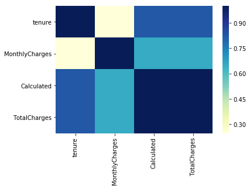

```python
corr = df[['tenure', 'MonthlyCharges', 'Calculated', 'TotalCharges']].corr()
print(corr)
sns.heatmap(corr,
            xticklabels=corr.columns.values,
            yticklabels=corr.columns.values, cmap="YlGnBu")
```

The rows where total charges is 0, where tenure is 0 will be removed. This is because within such a short period of time, the customer may not have had the time to churn. These data might have been useful if there was a churn during that period, which would help us gain more insights into this problem. However, for this case, it will be removed from the dataset.

```python
df = df.drop(columns="Calculated")
df = df[df.TotalCharges > 0]
```

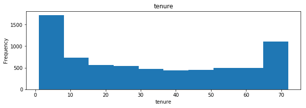

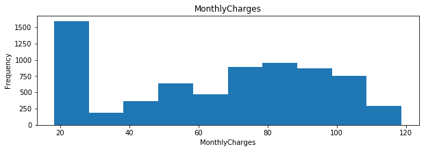

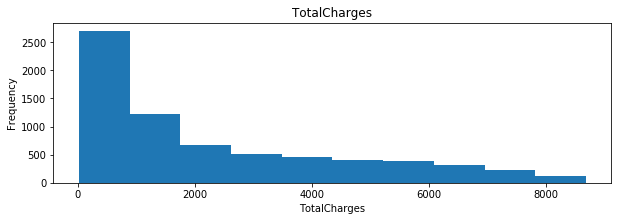

```python
variables = ['tenure', 'MonthlyCharges', 'TotalCharges']
for i in range(len(variables)):
    fig = plt.figure(figsize=[10,10])
    ax = fig.add_subplot(3, 1, i+1)
    n, bins, patches = ax.hist(df[variables[i]])
    ax.set_xlabel(variables[i])
    ax.set_title(variables[i])
    ax.set_ylabel('Frequency')
```

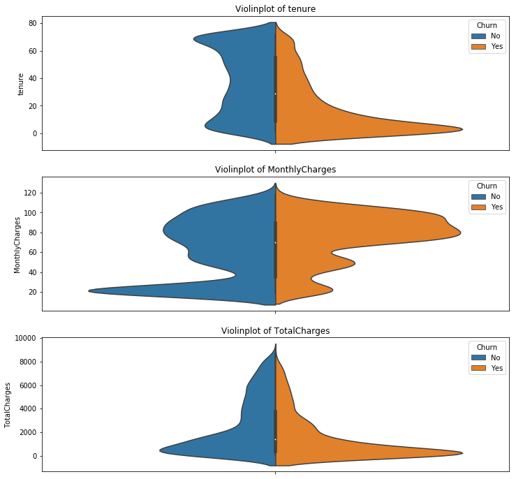

```python
df["Dummy"] = ""
f, axes = plt.subplots(nrows=3, ncols=1, figsize=[12,12])
axes = axes.flatten()
y_vars = ['tenure', 'MonthlyCharges', 'TotalCharges']

for i in range(len(y_vars)):
    sns.violinplot(x="Dummy", y=y_vars[i], hue="Churn", data=df, ax=axes[i], split=True, scale="area")
    axes[i].set_xlabel("")
    axes[i].set_title("Violinplot of " + y_vars[i])
df = df.drop(columns="Dummy")
# sns.set(style="ticks")
# sns.pairplot(df, hue="Churn")
```

## Categorical Variables

```python
categorical = ['gender', 'SeniorCitizen', 'Partner', 'Dependents',
               'PhoneService', 'MultipleLines', 'InternetService', 'OnlineSecurity',
               'OnlineBackup', 'DeviceProtection', 'TechSupport', 'StreamingTV',
               'StreamingMovies', 'Contract', 'PaperlessBilling', 'PaymentMethod', 'Churn']
for col in categorical:
    print(col + " : " +str(df[col].unique()))
```

```
gender : ['Female' 'Male']
SeniorCitizen : [0 1]
Partner : ['Yes' 'No']
Dependents : ['No' 'Yes']
PhoneService : ['No' 'Yes']
MultipleLines : ['No phone service' 'No' 'Yes']
InternetService : ['DSL' 'Fiber optic' 'No']
OnlineSecurity : ['No' 'Yes' 'No internet service']
OnlineBackup : ['Yes' 'No' 'No internet service']
DeviceProtection : ['No' 'Yes' 'No internet service']
TechSupport : ['No' 'Yes' 'No internet service']
StreamingTV : ['No' 'Yes' 'No internet service']
StreamingMovies : ['No' 'Yes' 'No internet service']
Contract : ['Month-to-month' 'One year' 'Two year']
PaperlessBilling : ['Yes' 'No']
PaymentMethod : ['Electronic check' 'Mailed check' 'Bank transfer (automatic)'
 'Credit card (automatic)']
Churn : ['No' 'Yes']
```

```python
dictionary = dictinct_column_counts(df, columns)
del dictionary["Churn"]

internet_cols = ["InternetService", "OnlineSecurity", "OnlineBackup",
                   "DeviceProtection", "TechSupport", "StreamingTV", "StreamingMovies"]
mobile_cols = ["PhoneService","MultipleLines"]
personal_cols = ["gender", "SeniorCitizen", "Partner", "Dependents"]
others_cols = [x for x in categorical if x not in list(internet_cols+mobile_cols+personal_cols+["Churn"])]

internet_linked = {k:v for (k,v) in dictionary.items() if k in internet_cols}
mobile_linked = {k:v for (k,v) in dictionary.items() if k in mobile_cols}
personal_details = {k:v for (k,v) in dictionary.items() if k in personal_cols}
others = {k:v for k,v in dictionary.items() if k in others_cols}

print(internet_linked)
print(mobile_linked)
print(personal_details)
print(others)
```

```
{'InternetService': 3, 'OnlineSecurity': 3, 'OnlineBackup': 3, 'DeviceProtection': 3, 'TechSupport': 3, 'StreamingTV': 3, 'StreamingMovies': 3}
{'PhoneService': 2, 'MultipleLines': 3}
{'gender': 2, 'SeniorCitizen': 2, 'Partner': 2, 'Dependents': 2}
{'Contract': 3, 'PaperlessBilling': 2, 'PaymentMethod': 4}
```

The EDA for Categorical variables will be split into four parts:

1. Internet service linked analysis
2. Mobile service linked analysis
3. Analysis of personal details
4. Payment method/duration analysis

## Internet Services

```python
# This function checks if the correct number of unique numbers are expected
# For example if under internet service, filtered for value "No", the internet linked
# columns should reflect "No internet service"
# This function would check if there are any invalid rows

def check_unique(dataframe, g_index_name, value, g_columns, unique_vals):
    dataframe = df[df[g_index_name] == value]
    g = dataframe.groupby(g_index_name).agg({col: 'nunique' for col in g_columns})
    if g[g>unique_vals].dropna().shape[0] != 0:
        print(str(unique_vals) + " unique values expected but this is not the case")
    else:
        print(g_index_name + " value " + value + " has correct number of unique values")
g_cols =["OnlineSecurity", "OnlineBackup",
                   "DeviceProtection", "TechSupport", "StreamingTV", "StreamingMovies"]

check_unique(df, "InternetService", "No", g_cols, 1) # No internet service
check_unique(df, "InternetService", "DSL", g_cols, 2) # No, Yes
check_unique(df, "InternetService", "Fiber optic", g_cols, 2) # No, Yes
```

```
InternetService value No has correct number of unique values
InternetService value DSL has correct number of unique values
InternetService value Fiber optic has correct number of unique values
```

```
                  InternetService  OnlineSecurity  OnlineBackup  \
InternetService          1.000000        0.607412      0.650084
OnlineSecurity           0.607412        1.000000      0.621270
OnlineBackup             0.650084        0.621270      1.000000
DeviceProtection         0.662685        0.748684      0.600952
TechSupport              0.609422        0.790951      0.616520
StreamingTV              0.712715        0.701526      0.603551
StreamingMovies          0.708336        0.704672      0.606037

                  DeviceProtection  TechSupport  StreamingTV  StreamingMovies
InternetService           0.662685     0.609422     0.712715         0.708336
OnlineSecurity            0.748684     0.790951     0.701526         0.704672
OnlineBackup              0.600952     0.616520     0.603551         0.606037
DeviceProtection          1.000000     0.767659     0.762742         0.766635
TechSupport               0.767659     1.000000     0.737211         0.737126
StreamingTV               0.762742     0.737211     1.000000         0.809507
StreamingMovies           0.766635     0.737126     0.809507         1.000000
```

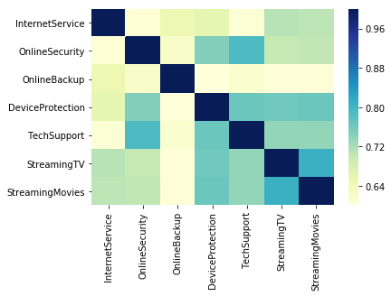

```python
corr = df[internet_cols].apply(lambda x : pd.factorize(x)[0]).corr(method='pearson', min_periods=1)
print(corr)
sns.heatmap(corr,
            xticklabels=corr.columns.values,
            yticklabels=corr.columns.values, cmap="YlGnBu")
```

From this chart, we can infer that these variables are correlated. This behaviour should be analysed further to gain more insights into how the variables act with one another.

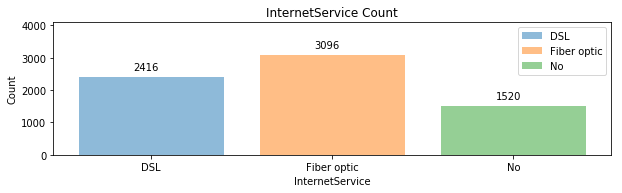

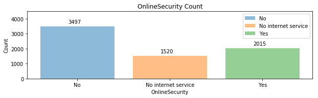

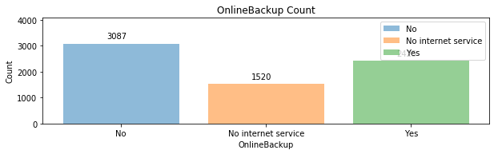

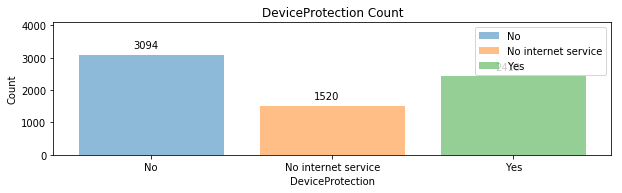

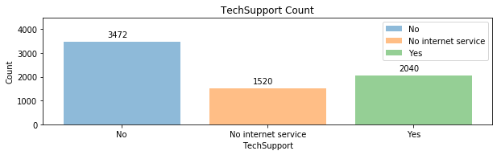

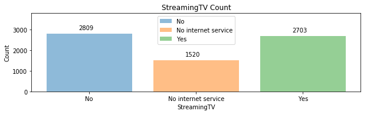

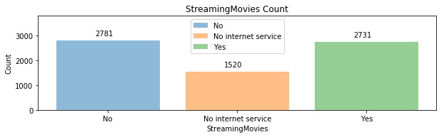

```python
def plot_cat_variables(df, cols, width, height):
    for i in range(len(cols)):
        fig = plt.figure(figsize=[width, height])
        ax = fig.add_subplot(len(cols), 1, i+1)
        current_data = df.groupby(cols[i]).agg('count')
        current_data = current_data[current_data.columns[0]]
        x_var = list(current_data.index)

        for position in range(len(current_data)):
            plt.bar(position, current_data[position], align='center', alpha=0.5, label=x_var[position])
        plt.xticks(list(range(0,len(x_var))), x_var)
        plt.xlabel(cols[i])
        plt.ylim(0, (max(current_data)+1000))
        plt.ylabel("Count")
        plt.title(cols[i] + " Count")
        plt.legend()
        for j in range(len(current_data)):
            plt.text(x=j-0.1 , y=current_data[j]+200, s=current_data[j], size = 10)

plot_cat_variables(df, internet_cols, 10, 20)
```

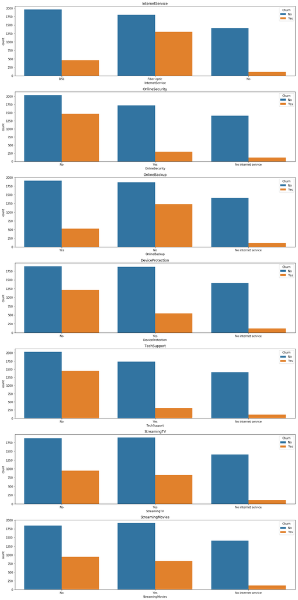

```python
def plot_cat_tar_relation(df, col, target, width, height):
    f, axes = plt.subplots(nrows=len(col), ncols=1, figsize=[width, height])
    axes = axes.flatten()
    for i in range(len(col)):
        sns.countplot(x=col[i], hue=target, palette ={"No":"C0","Yes":"C1"},
                      data=df, ax=axes[i])
        axes[i].set_xlabel(col[i])
        axes[i].set_title(col[i])
    f.tight_layout()
plot_cat_tar_relation(df, internet_cols, "Churn", 15, 30)
```

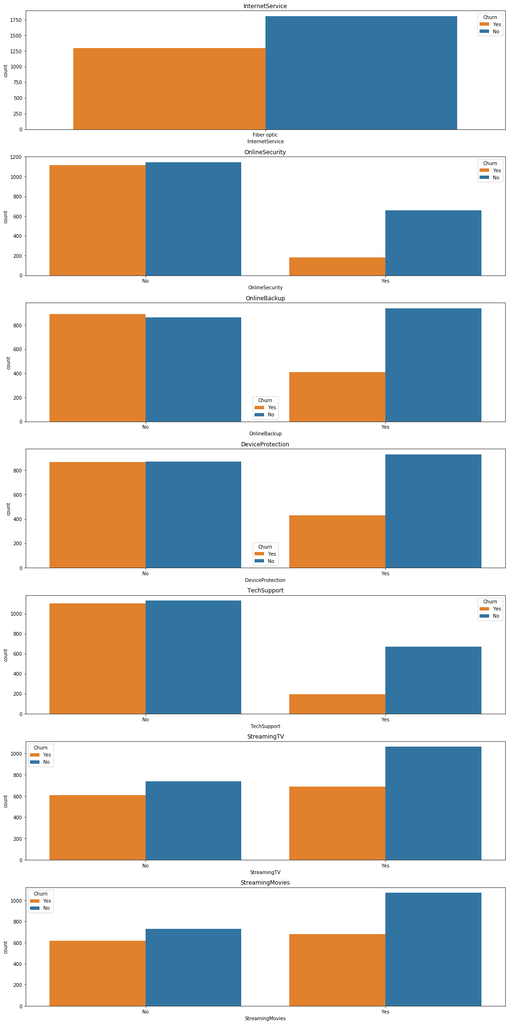

```python
plot_cat_tar_relation(df[df["InternetService"]=="Fiber optic"], internet_cols, "Churn", 15, 30)
```

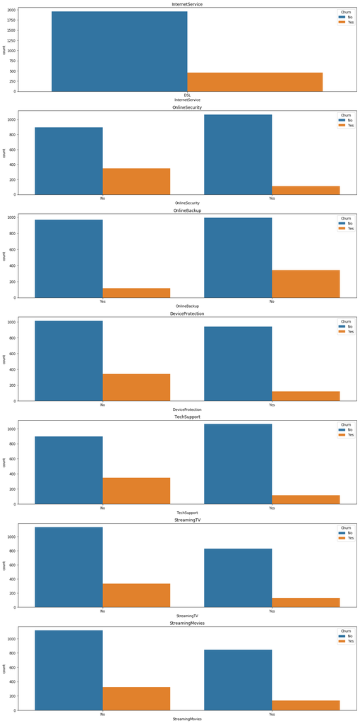

```python
plot_cat_tar_relation(df[df["InternetService"]=="DSL"], internet_cols, "Churn", 15, 30)
```

## Mobile

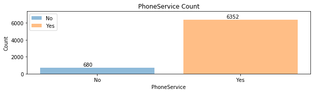

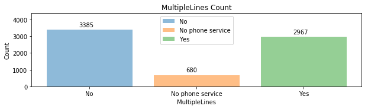

```python
plot_cat_variables(df, mobile_cols, 10, 5)
```

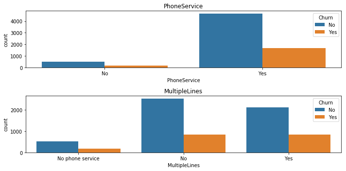

```python
plot_cat_tar_relation(df, mobile_cols, "Churn", 10, 5)
```

```python
no_ps = df[df["PhoneService"] == "No"][["Churn", "PhoneService"]].groupby("Churn").agg("count")
print(no_ps["PhoneService"][1]/no_ps["PhoneService"][0])
yes_ps = df[df["PhoneService"] == "Yes"][["Churn", "PhoneService"]].groupby("Churn").agg("count")
print(yes_ps["PhoneService"][1]/yes_ps["PhoneService"][0])
```

```
0.3333333333333333
0.3651407693960885
```

From the data analysis of Mobile Columns, we can see that the ratios of Churn to No Churn is the same whether the customer subscribed to Phone Service or not. Hence, these variables might not be good for prediction. We should keep this in mind during feature selection.

## Personal

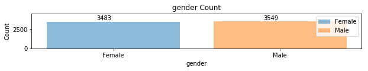

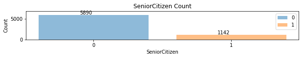

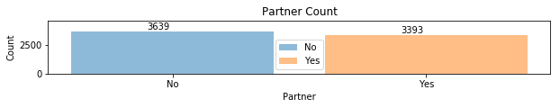

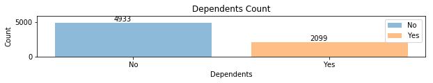

```python
plot_cat_variables(df, personal_cols, 10, 5)
```

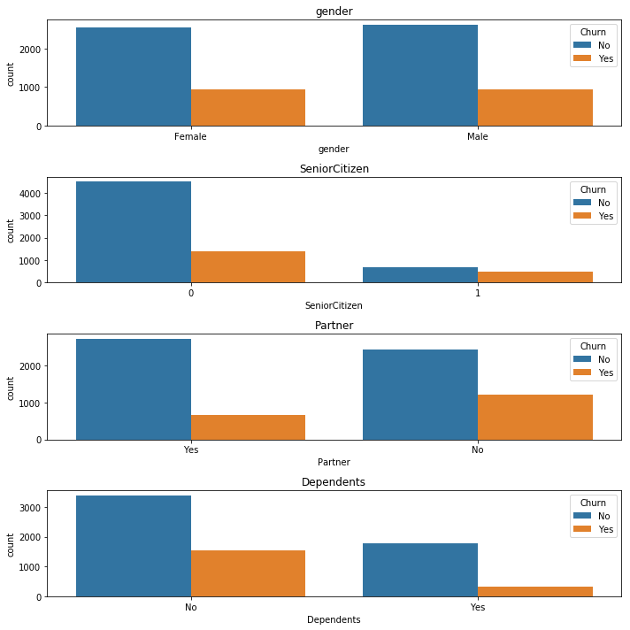

```python
plot_cat_tar_relation(df, personal_cols, "Churn", 10, 10)
```

Gender does not seem to be a good predictor as the Churn outcome seems to be indifferent between different Gender. Senior Citizen, Dependents and Partner seem to affect churn rate to a certain extent. However, its direct impact is not as straightforward.

# Others

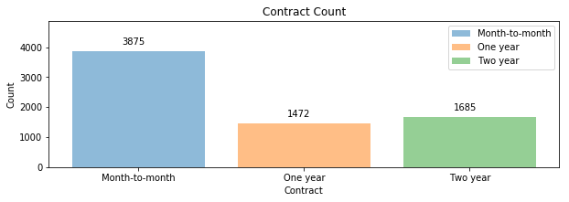

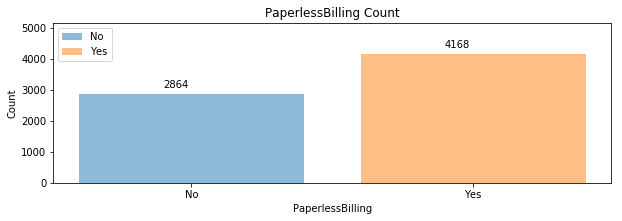

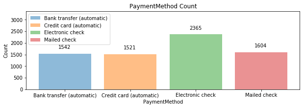

```python
plot_cat_variables(df, others_cols, 10, 10)
```

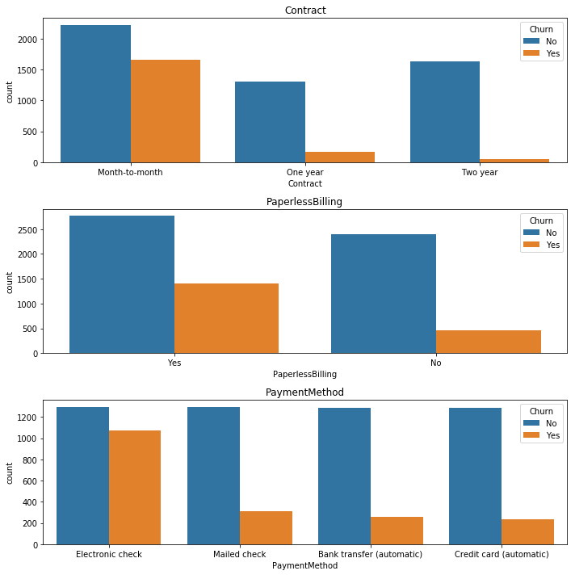

```python
plot_cat_tar_relation(df, others_cols, "Churn", 10, 10)
```

Contract might be a good predictor of Churn rate. Month-to-month churn is much more significant as compared to the Two year contract. Paperless billing and payment method seem to have a difference on churn rates. However, their direct impact is not intuitive.

# Pre-Processing

```python
start_df = deepcopy(df)
```

```python
from sklearn.preprocessing import LabelEncoder
from sklearn.preprocessing import MinMaxScaler

binary_columns = [k for k, v in df_col_counts.items() if v == 2]
other_columns = [k for k, v in df_col_counts.items() if v > 2 and v < 10]

labelEncoder = LabelEncoder()
for col in binary_columns:
    df[col] = labelEncoder.fit_transform(df[col])

df = pd.get_dummies(data=df ,columns=other_columns)
df.head()
```

|  | customerID | gender | SeniorCitizen | Partner | Dependents | tenure | PhoneService | PaperlessBilling | MonthlyCharges | TotalCharges | ... | StreamingMovies_No | StreamingMovies_No internet service | StreamingMovies_Yes | Contract_Month-to-month | Contract_One year | Contract_Two year | PaymentMethod_Bank transfer (automatic) | PaymentMethod_Credit card (automatic) | PaymentMethod_Electronic check | PaymentMethod_Mailed check |
| --- | --- | --- | --- | --- | --- | --- | --- | --- | --- | --- | --- | --- | --- | --- | --- | --- | --- | --- | --- | --- | --- |
| 0 | 7590-VHVEG | 0 | 0 | 1 | 0 | 1 | 0 | 1 | 29.85 | 29.85 | ... | 1 | 0 | 0 | 1 | 0 | 0 | 0 | 0 | 1 | 0 |
| 1 | 5575-GNVDE | 1 | 0 | 0 | 0 | 34 | 1 | 0 | 56.95 | 1889.50 | ... | 1 | 0 | 0 | 0 | 1 | 0 | 0 | 0 | 0 | 1 |
| 2 | 3668-QPYBK | 1 | 0 | 0 | 0 | 2 | 1 | 1 | 53.85 | 108.15 | ... | 1 | 0 | 0 | 1 | 0 | 0 | 0 | 0 | 0 | 1 |
| 3 | 7795-CFOCW | 1 | 0 | 0 | 0 | 45 | 0 | 0 | 42.30 | 1840.75 | ... | 1 | 0 | 0 | 0 | 1 | 0 | 1 | 0 | 0 | 0 |
| 4 | 9237-HQITU | 0 | 0 | 0 | 0 | 2 | 1 | 1 | 70.70 | 151.65 | ... | 1 | 0 | 0 | 1 | 0 | 0 | 0 | 0 | 1 | 0 |

5 rows × 42 columns

```python
scaler = MinMaxScaler()
features_std = scaler.fit_transform(df[continuous])
features_df = pd.DataFrame(features_std,columns=continuous)

final_df = deepcopy(df)

for column in features_df.columns:
    final_df[column] = features_df[column]
```

```python
final_df.to_csv("churn_processed.csv")
```